# An Introduction to Statistical Learning (2013)

Solutions to Applied Exercises

by Brian Hassett

# Chapter 10 Unsupervised Learning

This notebook is a rough outline of solutions to the applied exercises in Chapter 10 of **An Introduction to Statistical Learning** (James et al. (2013)[^1]).

## Setup

```r
library(ISLR)
library(cowplot)
library(tidyverse)
library(patchwork)
theme_set(theme_bw())

# Load my functions:
source("/home/brian/R/dir/Util/bh_functions.R")

# Colors:
ISLR_blue <- "#176FC0"
ISLR_brown <- "#94340E"
ISLR_lightblue <- "#68A5DB"
ISLR_orange <- "#CC5318"

# Return vector of the names of numeric columns in a data frame:
numeric_cols <- function(df) {
  is_numeric_cols <- map_lgl(df, is.numeric)
  return(names(df)[is_numeric_cols])
}

# Plot histograms and return a list of them:
plot_histogram <- function(df, var) {
  g <- ggplot(data = df, aes(x = .data[[var]])) + # Ref for passing var names to functions for plots: https://stackoverflow.com/a/55524126
    geom_histogram(bins = 30,
                   color = "white")
  return(g)
}

# Plot boxplots and return a list of them:
plot_boxplot <- function(df, var1, var2) {
  g <- ggplot(data = df, aes(x = .data[[var1]], y = .data[[var2]])) +
     geom_boxplot()
  return(g)
}
```

## Exercise 7

Calculate the euclidean distances and correlations ($r_ij$):

```r
X.scale <- t(scale(t(USArrests))) # scale observations, not features (https://altaf-ali.github.io/ISLR/chapter10/solutions.html)

euc <- dist(X.scale)
corr <- as.dist(1 - cor(t(X.scale))) # 1 - r_ij
```

Plot the squared euclidean distance and $1 - r_ij$:

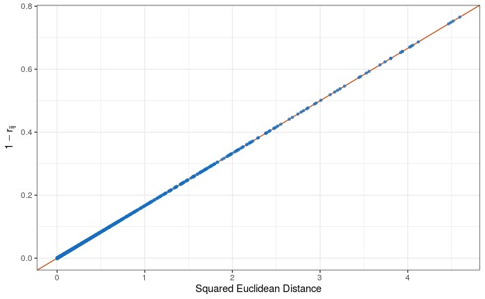

```r
# Plot the values
data.frame(x = as.numeric(euc^2), y = as.numeric(corr)) %>%
  ggplot() +
  geom_abline(intercept = 0, slope = 1/6, color = ISLR_orange) +
  geom_point(aes(x, y), color = ISLR_blue, size = 1, alpha = 0.7) +
  labs(x = "Squared Euclidean Distance", y = expression(1 - r[ij]))
```

The plot shows a straight line through the points with slope 1/6.

## Exercise 8

### (a)

Calculate the standard deviations and variance using the `sdev` output of `prcomp()`:

```r
pr.out <- prcomp(USArrests, scale = TRUE)
pr.out$sdev
```

```
[1] 1.5748783 0.9948694 0.5971291 0.4164494
```

Calculate the variances:

```r
pr.out.var <- pr.out$sdev^2
pr.out.var
```

```
[1] 2.4802416 0.9897652 0.3565632 0.1734301
```

Calculate the proportion of variance explained (PVE):

```r
pr.out.pve <- pr.out.var / sum(pr.out.var)
pr.out.pve %>% round(2)
```

```
[1] 0.62 0.25 0.09 0.04
```

Plot the PVE:

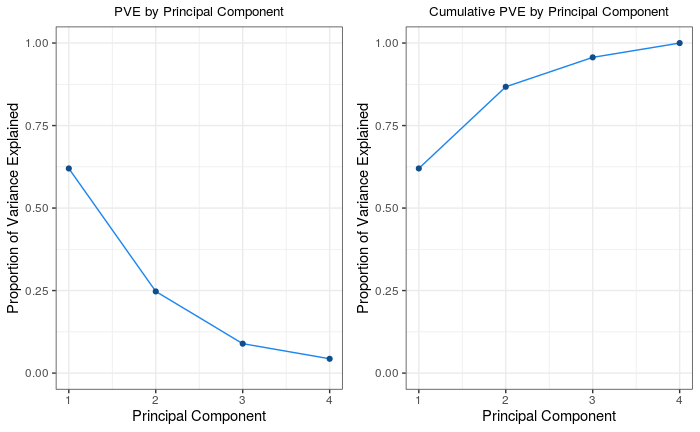

### (b)

We now calculate the PVE by using Equation 10.8 directly:
$$\frac{\sum_{i=1}^n\left(\sum_{j=1}^p \phi_{jm} x_{ij}\right)^2}{\sum_{j=1}^p \sum_{i=1}^nx^2_{ij}} \hspace{2cm} (10.8)$$

The principal component loading scores are labeled in the output of `prcomp` as `x`:

```r
pr.out$x %>% head()
```

```
                  PC1        PC2         PC3          PC4
Alabama    -0.9756604  1.1220012 -0.43980366  0.154696581
Alaska     -1.9305379  1.0624269  2.01950027 -0.434175454
Arizona    -1.7454429 -0.7384595  0.05423025 -0.826264240
Arkansas    0.1399989  1.1085423  0.11342217 -0.180973554
California -2.4986128 -1.5274267  0.59254100 -0.338559240
Colorado   -1.4993407 -0.9776297  1.08400162  0.001450164
```

For demonstration purposes, manually obtain the first principal component score for Alabama:

```r
# Scale the data and view the Alabama row:
USArrests %>%
  scale() %>%
  .[1, ]
```

```
      Murder      Assault     UrbanPop         Rape
 1.242564084  0.782839347 -0.520906615 -0.003416473
```

```r
# The first principal component loadings:
pr.out$rotation[, 1]
```

```
    Murder    Assault   UrbanPop       Rape
-0.5358995 -0.5831836 -0.2781909 -0.5434321
```

```r
# Multiply the scaled data values by the loadings, then sum to obtain the score:
((USArrests %>% scale() %>%  .[1, ]) * pr.out$rotation[, 1]) %>%
  sum()
```

```
[1] -0.9756604
```

```r
# Check that it matches the score calculated by prcomp():
pr.out$x[1, 1]
```

```
[1] -0.9756604
```

The variance explained by the $m$th principal component (the top half of (10.8)) is the sum of the squared principal component scores. For the first principal component ($m=1$) the variance explained is:

```r
(pr.out$x[ , 1])^2 %>% sum()
```

```
[1] 121.5318
```

The total variance in the data (bottom half of (10.8)) is the sum of the squares of the data values (remember to scale the values before summing):

```r
var.total <- scale(USArrests)^2 %>% sum()
var.total
```

```
[1] 196
```

Then the proportion of variance explained by the first principal component is found dividing the two (as in (10.8)):

```r
((pr.out$x[ , 1])^2 %>% sum() / var.total) %>% round(2)
```

```
[1] 0.62
```

Repeat for all four principal components:

```r
pve.10.8 <- map_dbl(1:4, function(m) (pr.out$x[ , m])^2 %>% sum() / var.total)
pve.10.8 %>% round(2)
```

```
[1] 0.62 0.25 0.09 0.04
```

Plot the results:

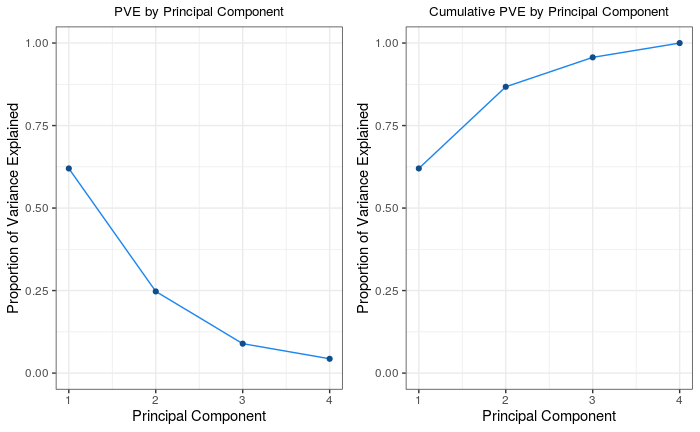

The results are the same as those calculated using `sdev`.

## Exercise 9

View data:

|  | Murder | Assault | UrbanPop | Rape |
| --- | --- | --- | --- | --- |
| Alabama | 13.2 | 236 | 58 | 21.2 |
| Alaska | 10.0 | 263 | 48 | 44.5 |
| Arizona | 8.1 | 294 | 80 | 31.0 |
| Arkansas | 8.8 | 190 | 50 | 19.5 |
| California | 9.0 | 276 | 91 | 40.6 |
| Colorado | 7.9 | 204 | 78 | 38.7 |

### (a)

Using hierarchical clustering with complete linkage and Euclidean distance, cluster the states:

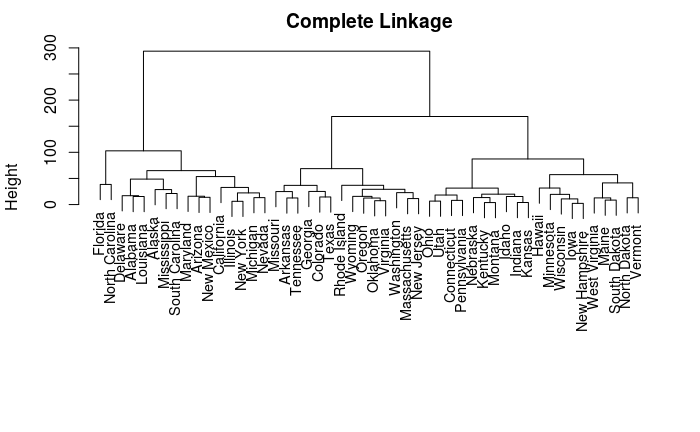

### (b)

Cut the dendrogram at a height that results in three distinct clusters:

| state | cluster |
| --- | --- |
| Alabama | 1 |
| Alaska | 1 |
| Arizona | 1 |
| California | 1 |
| Delaware | 1 |
| Florida | 1 |
| Illinois | 1 |
| Louisiana | 1 |
| Maryland | 1 |
| Michigan | 1 |

[output cut: 40 more lines]

### (c)

Hierarchically cluster the states using complete linkage and Euclidean distance, *after scaling the variables to have standard deviation one*:

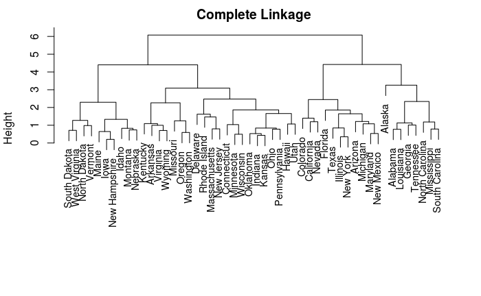

Clusters:

| state | cluster |
| --- | --- |
| Alabama | 1 |
| Alaska | 1 |
| Georgia | 1 |
| Louisiana | 1 |
| Mississippi | 1 |
| North Carolina | 1 |
| South Carolina | 1 |
| Tennessee | 1 |
| Arizona | 2 |
| California | 2 |

[output cut: 40 more lines]

Compare:

```r
table(cut1, cut2)
```

[output not shown]